# Data Analysis with R

Nyaosi Mogaka

September, 2018

## Introduction

Data analysis is a process of inspecting, cleansing, transforming, and modelling data with the goal of discovering useful information, informing conclusions, and supporting decision-making. Data analysis plays a role in making decisions more scientific and helping businesses operate more effectively.

Let’s start off by loading some libraries and the data to use.

```r
#Load Libraries
library(readxl)
library(dplyr)
library(stringr)
library(ggplot2)
library(tinytex)

#Import Data
rosters <- read_xlsx("C:/Users/User/Desktop/FCSS18.xlsx", sheet = "Academy Staff Rooster")
titles <- read_xlsx("C:/Users/User/Desktop/FCSS18.xlsx", sheet = "Job Titles")
```

### The Data

The structure of the data used in this exercise can be seen below:

```r
str(rosters)
```

```
## tibble [11,907 × 17] (S3: tbl_df/tbl/data.frame)
##  $ No                     : chr [1:11907] "AM025" "AM026" "AM027" "AM034" ...
##  $ Full Names             : chr [1:11907] "Maureen Geofrey Iminza" "Shamim Nungari Mutunge" "Teresia Iminza Mburu" "John Mutunge Kibirech" ...
##  $ Status                 : chr [1:11907] "Terminated" "Terminated" "Terminated" "Terminated" ...
##  $ Job Position           : chr [1:11907] "Academy Manager" "Academy Manager" "Academy Manager" "Academy Manager" ...
##  $ Contract Code          : chr [1:11907] "PERMANENT" "PERMANENT" "PERMANENT" "PERMANENT" ...
##  $ Academy Neighbourhood  : chr [1:11907] "ASEMBO BAY-SYA" "BANGAL-TAN" "MACHAKOS-MCS" "KWALE-KLE" ...
##  $ Base Academy           : chr [1:11907] "KIRATHIMO-KBU" "KIBERA BUKHUNGU-NBO" "MACHAKOS-MCS" "MACHAKOS-MCS" ...
##  $ Date of Birth          : POSIXct[1:11907], format: "1999-04-20" "1984-11-09" ...
##  $ Employment Date        : POSIXct[1:11907], format: "2011-01-01" "2011-01-01" ...
##  $ Contract Start Date    : POSIXct[1:11907], format: "2012-01-01" "2012-01-01" ...
##  $ Gender                 : chr [1:11907] "Female" "Female" "Female" "Male" ...
##  $ Class                  : chr [1:11907] "0" "0" "0" "0" ...
##  $ Highest Level Education: chr [1:11907] "KCSE" "KCSE" "KCSE" "KCSE" ...
##  $ High School Grade      : chr [1:11907] NA NA NA NA ...
##  $ Exit Date              : POSIXct[1:11907], format: "2012-11-30" "2011-07-01" ...
##  $ Reason for Separation  : chr [1:11907] "SUMMARY DISMISSAL" "END-OF-CONTRACT" "VOLUNTARY RESIGNATION" NA ...
##  $ Certification          : chr [1:11907] NA NA NA NA ...
```

The *rosters* dataset represents Human Resource people records with self-explanatory descriptors like *No* which is the unique record identifier, *Full Names* of the person, their employment *Status*, *Job Position*, *Contract Code*, the *Academy Neighbourhood* describing a specific location, while the *Base Academy* is a broader geographical location for multiple academy neighborhoods. *Date of Birth*, *Employment Date*, *Contract Start Date*, *Gender*, *Class*, *Highest Level Education*, and *High School Grade* are self explanatory variables. The *Exit Date* represents when the person left the organisation and there’s also a *Reason for Separation* variable.

```r
str(titles)
```

```
## tibble [208 × 7] (S3: tbl_df/tbl/data.frame)
##  $ S.no             : num [1:208] 1 2 3 4 5 6 7 8 9 10 ...
##  $ Department       : chr [1:208] "Executive" "Academics Leadership" "Production" "Production" ...
##  $ Group            : chr [1:208] "Executive" "Academics" "Academics" "Academics" ...
##  $ Specialisation   : chr [1:208] NA NA NA NA ...
##  $ Rank/Level       : chr [1:208] "Chief Executive Officer" "Chief Academic Officer" "Coordinator" "Editor" ...
##  $ Updated Job title: logi [1:208] NA NA NA NA NA NA ...
##  $ Territory        : chr [1:208] "Shared Services" "Shared Services" "Shared Services" "Kenya" ...
```

The *titles* dataset represents job titles, duties and roles assigned to the Human Resource pool, with descriptors like *S.no*, *Department*, *Group*, *Specialisation*, *Rank/Level*, *Updated Job Title* and *Territory*.

### Data Wrangling

Data wrangling is the process of transforming data from a certain form into another format, with the intent of making it more appropriate and valuable for a variety of downstream purposes such as analytics.

On the titles dataset, we create a new job titles column with the format **“specialization + rank, department”** , exceptions to this rule are:

- If department is *Executive* or starts contains the word *Chief*, use *specialization + rank*
- If rank has the words *Lead* or *Senior*, these should prefix the job title
- If specialization is *Project Management*, job title format is inverted i.e. starts with *rank + specialization, department*
- If department contains the word *Leadership*, replace department with group in the job title

```r
q1 <- titles %>%
  mutate(nn = if_else(Department == "Executive" | str_detect(`Rank/Level`, "Chief"), str_c(str_replace_na(Specialisation), " ", `Rank/Level`),
                      if_else(str_detect(`Rank/Level`, "Lead"), str_c("Lead ", str_replace_na(Specialisation), " ", str_remove(`Rank/Level`, "Lead"), ", ", Department ),
                              if_else(str_detect(`Rank/Level`, "Senior"), str_c("Senior ", str_replace_na(Specialisation), " ", str_remove(`Rank/Level`, "Senior"), ", ", Department ),
                                      if_else(str_detect(Department, "Leadership") | str_detect(titles$Department, "Leadership") & is.na(titles$Specialisation), str_c(str_replace_na(Specialisation), " ", `Rank/Level`, ", ", Group), str_c(str_replace_na(Specialisation), " ", `Rank/Level`, ", ", Department))))))

q1$`Updated Job title` <- str_remove(q1$nn, "NA ")
```

The updated job titles can be seen below:

| x |
| --- |
| Chief Executive Officer |
| Chief Academic Officer |
| Coordinator, Production |
| Editor, Production |
| Senior Graphic Designer, Production |
| Graphic Designer, Production |

An extended sample of the Updated Job Titles can be seen below:

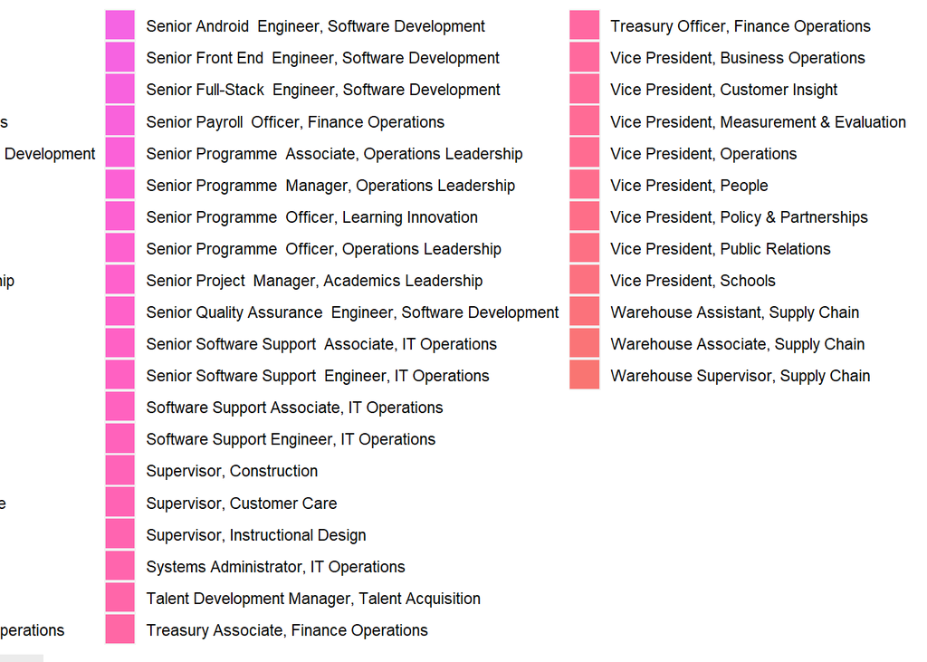

### Insights

Users may have particular data points of interest within a data set, as opposed to the general messaging outlined above. Such low-level user analytic activities are presented in the following table.

The best way to get insights from data is to ask yourself questions about the data, and see if the data can answer these questions. These questions can belong to different analytic techniques like:

- *Retrieve Value* : Given a set of specific cases, find attributes of those cases ie. What are the values of attributes {X, Y, Z, …} in the data cases {A, B, C, …}? eg. How many active employees have a degree as their highest level of education?
- *Filter* : Given some concrete conditions on attribute values, find data cases satisfying those conditions. ie. Which data cases satisfy conditions {A, B, C…}? eg. How many active teachers are there for each job title?
- *Compute Derived Value* : Given a set of data cases, compute an aggregate numeric representation of those data cases. ie. What is the value of aggregation function F over a given set S of data cases? eg. What is the median age of male employees vs female?
- *Find Extremum* : Find data cases possessing an extreme value of an attribute over its range within the data set. ie. What are the top/bottom N data cases with respect to attribute A? eg. On average, which academy has the youngest employees, which has the oldest?
- *Sort* : Given a set of data cases, rank them according to some ordinal metric. ie. What is the sorted order of a set S of data cases according to their value of attribute A? eg. Which Base academies with the highest turnover of employees?

The questions I asked myself were:

##### What is the most common job title across all territories?

```r
q2 <- q1 %>% group_by(`Updated Job title`) %>%
  count(`Updated Job title`) %>%
  arrange(desc(n))
```

| Updated Job title | n |
| --- | --- |
| Director, Academics | 3 |
| Associate, Academics | 2 |
| Director, Development | 2 |
| Director, Operations | 2 |
| Director, People | 2 |
| Manager, Academics | 2 |

##### Which territory has the least job titles assigned?

```r
q3 <- q1 %>% group_by(Territory) %>%
  count(Territory) %>%
  arrange(desc(n))
```

| Territory | n |
| --- | --- |
| Shared Services | 71 |
| Kenya | 40 |
| Uganda | 26 |
| Nigeria - Lagos | 23 |
| Nigeria - EDO | 19 |
| India | 9 |

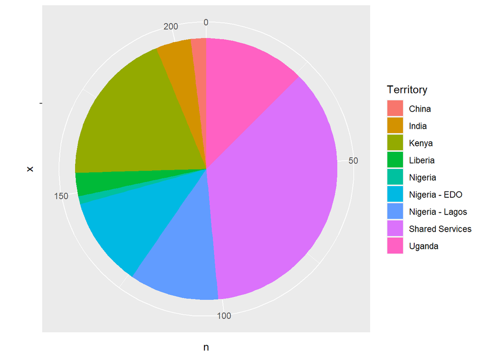

##### Looking at the rosters dataset;

- How many active teachers does Company X have for each job title?

  ```r
  q4 <- rosters %>%
    group_by(Status) %>%
    count(`Job Position`) %>%
    arrange(desc(n))

  q4i <- filter(q4, Status == "Active")
  ```

  | Status | Job Position | n |
  | --- | --- | --- |
  | Active | Permanent Teacher | 3284 |
  | Active | Academy Manager | 293 |
  | Active | Permanent Substitute Teacher | 113 |
  | Active | Permanent Travelling Sub Teacher | 59 |
  | Active | Substitute Academy Manager | 24 |
  | Active | Permanent Relocating Teacher | 19 |

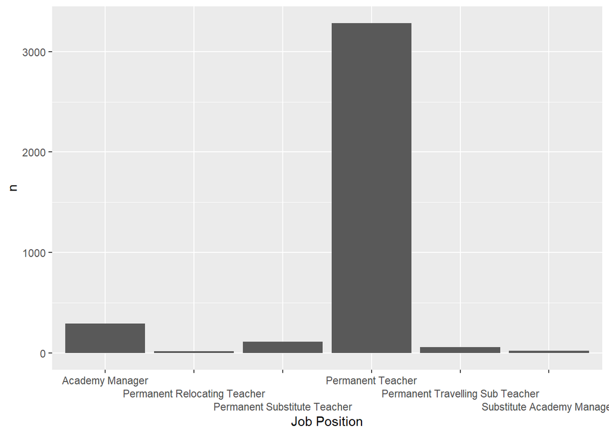

- What is the age of each teacher?

  ```r
  miaka <- rosters %>%
    mutate(age = 2022 - as.numeric(str_sub(`Date of Birth`,1,4)))
  ```

  | Job Position | age |
  | --- | --- |
  | Academy Manager | 23 |
  | Academy Manager | 38 |
  | Academy Manager | 36 |
  | Academy Manager | 23 |
  | Academy Manager | 35 |
  | Academy Manager | 35 |

- What is the median age of male employees vs female?

  ```r
  options(knitr.kable.NA = '')
  q4iii <- miaka %>%
    group_by(Gender) %>%
    summarise(median(age, na.rm = TRUE))
  ```

  | Gender | median(age, na.rm = TRUE) |
  | --- | --- |
  | Female | 32 |
  | Male | 32 |
  |  | 33 |

- On average, which academy has the youngest employees, which has the oldest?

  ```r
  q4iv <- aggregate(miaka[, 18], list(miaka$`Base Academy`), mean) %>%
    filter(age %in% range(age))
  ```

  | Group.1 | age |
  | --- | --- |
  | KIBERA GATIKWIRA-NBO | 48 |
  | KINANGO | 25 |

- Other inferences can be made from this dataset, like, which base academies highest the highest turnover of people?

  ```r
  #Turnover at base academies
  q4va <- miaka %>% group_by(`Base Academy`, Status) %>%
    count(Status) %>%
    arrange(desc(n))
  ```

  | Base Academy | Status | n |
  | --- | --- | --- |
  | KOROGOCHO-NBO | Terminated | 44 |
  | MADOGO-TAN | Terminated | 37 |
  | THOGOTO-KBU | Terminated | 37 |
  | MAI MAHIU-NKU | Terminated | 36 |
  | GACHORORO-KBU | Terminated | 35 |
  | GIKAMBURA-KBU | Terminated | 35 |

- Or maybe the active employees with a degree as their highest level of education?

  ```r
  q4vb <- miaka %>%
    group_by(`Base Academy`, Status) %>%
    count(`Highest Level Education`) %>%
    filter(`Highest Level Education` == "Degree", Status == "Active")
  ```

  | Base Academy | Status | Highest Level Education | n |
  | --- | --- | --- | --- |
  | GIKAMBURA-KBU | Active | Degree | 1 |
  | KIBABII-BGM | Active | Degree | 1 |
  | MACHINE-NKU | Active | Degree | 1 |
  | MAKINDU-MUE | Active | Degree | 1 |
  | MATUNDA-KAK | Active | Degree | 1 |
  | MISHOMORONI-MBA | Active | Degree | 1 |
  | NDUMBERI-KBU | Active | Degree | 1 |
  | SHIANDA-KAK | Active | Degree | 1 |
  | SIRISIA-BGM | Active | Degree | 1 |
  | THOGOTO-KBU | Active | Degree | 1 |
  | UMOJA-NKU | Active | Degree | 1 |

## Conclusion

Performing effective data analysis involves obtaining relevant facts. These facts are then used to answer questions, support a conclusion or formal opinion, or to test hypotheses. Facts by definition are irrefutable, therefore, when analysis is done, there should be consensus around the facts.

When performing data analysis, one should be aware of cognitive biases that can adversely affect analysis. For example, confirmation bias which is the tendency to search for, or interpret information in a way that confirms one’s preconceptions.

Effective analysts should also be adept with a variety of mathematical techniques, since bad math techniques may produce misleading results or may misinform.

Finally, when communicating analysis results, one may implement a variety of data visualization techniques to help communicate the message more clearly and efficiently to the audience.

Email me: nyaosi.mogaka at gmail.com